# Parameterized Report Example: Otisco

Zachary M. Smith

2/27/2020

# Introduction

This document was created during the *2020 NABs R Markdown workshop* and will serve as an example workflow for my future use of **R Markdown**. This document will represent an exploratory analysis of macroinvertebrate metrics and environmental variable associated with Otisco Lake.

# Workflow

1. Open R Studio
2. Create an R Project
3. Add a data folder to the R project directory
4. Create an R Markdown document
5. Use Knit to compile the document.

# Import Data

- `unique_id` (character) unique sample ID
- `lake` (character) lake code: caz = Cazenovia lake, onon = Onondaga, and ot = Otisco
- `lat` (numeric) latitude of sampling location
- `long` (numeric) longitude of sampling location
- `substrate_size_d50` (numeric) median partical size from pebble count
- `conductivity` (numeric) specific conductivity (µS/cm)
- `richness` (numeric) taxonomic richness
- `shannon` (numeric) Shannon-Wiener diversity index values
- `pct_ephemeroptera` (numeric) relative abundance of Ephemeroptera taxa
- `pct_amphipoda` (numeric) relative abundance of Amphipoda taxa
- `pct_diptera` (numeric) relative abundance of Diptera taxa
- `dom_1` (numeric) relative abundance of the most dominant taxon observed in each sample

```r
thesis.df <- read.csv(file.path(here::here(),
                                "data",
                                "zms_thesis_metrics.csv"),
                      stringsAsFactors = FALSE)
```

# Preprocessing

Load the **tidyverse** packages into the global environment.

```r
library(tidyverse)
```

```r
thesis.df <- thesis.df %>%
  mutate(lake = case_when(
    lake %in% "caz" ~ "Cazenovia",
    lake %in% "onon" ~ "Onondaga",
    lake %in% "ot" ~ "Otisco",
    TRUE ~ "ERROR"
  ),
  lake = factor(lake, levels = c("Onondaga",
                                 "Otisco",
                                 "Cazenovia")))
```

```r
thesis.df <- thesis.df %>%
  filter(lake %in% params$lake)
```

For more details about the **DT** package visit https://rstudio.github.io/DT/.

```r
library(DT)

datatable(thesis.df, options = list(scrollX = TRUE))
```

|  | unique_id | lake | lat | long | substrate_size_d50 | conductivity | richness | shannon | pct_ephemeroptera | pct_amphipoda | pct_diptera | dom_1 |
| --- | --- | --- | --- | --- | --- | --- | --- | --- | --- | --- | --- | --- |
| 1 | ot_1_1 | Otisco | 42.8937111 | -76.31353 | 37.70913377 | 378 | 16 | 3.3757989830575 | 3.92156862745098 | 28.4313725490196 | 22.5490196078431 | 28.4313725490196 |
| 2 | ot_10_1 | Otisco | 42.8404732 | -76.2587051 | 28.89887 | 368 | 14 | 3.14968531113372 | 2.1505376344086 | 31.1827956989247 | 49.4623655913978 | 30.1075268817204 |
| 3 | ot_11_1 | Otisco | 42.846508 | -76.2689514 | 36.75834736 | 373 | 18 | 2.67269008104696 | 6.16438356164384 | 51.3698630136986 | 26.7123287671233 | 50.6849315068493 |
| 4 | ot_12_1 | Otisco | 42.8524895 | -76.2792816 | 35.91878555 | 372 | 12 | 2.84968886332671 | 14.6788990825688 | 38.5321100917431 | 29.3577981651376 | 38.5321100917431 |
| 5 | ot_13_1 | Otisco | 42.8589745 | -76.2888336 | 42.939766 | 372 | 14 | 1.18092045844085 | 5.37190082644628 | 7.43801652892562 | 3.30578512396694 | 82.2314049586777 |
| 6 | ot_14_1 | Otisco | 42.8660507 | -76.2974777 | 26.58230615 | 374 | 17 | 2.79199921207011 | 2.24719101123596 | 47.1910112359551 | 41.5730337078652 | 46.0674157303371 |
| 7 | ot_15_1 | Otisco | 42.8736038 | -76.3053894 | 16.99403483 | 375 | 18 | 2.78296043776894 | 5.43478260869565 | 43.4782608695652 | 14.1304347826087 | 43.4782608695652 |
| 8 | ot_16_1 | Otisco | 42.8826752 | -76.3109665 | 26.58230615 | 376 | 13 | 1.82300404726156 | 0 | 71.5686274509804 | 18.6274509803922 | 70.5882352941177 |
| 9 | ot_2_1 | Otisco | 42.8893509 | -76.3006973 | 0.439970203 | 378 | 7 | 2.03496039742786 | 0 | 0 | 63.0630630630631 | 36.9369369369369 |
| 10 | ot_3_1 | Otisco | 42.8821716 | -76.2922134 | 2.691800385 | 382 | 10 | 1.71296707774017 | 0 | 4 | 89 | 70 |

[output cut: 6 more lines]

# Study Area

For more details about the **leaflet** package visit https://rstudio.github.io/leaflet/.

```r
library(leaflet)

pal <- colorFactor(c("#619Cff", "#F8766D", "#00BA38"),
                   domain = c("Cazenovia", "Onondaga", "Otisco"))

leaflet(data = thesis.df,
        options = leafletOptions(minZoom = 7,
                                 maxZoom = 13)) %>%
  addTiles() %>%
  addCircleMarkers(~long, ~lat,
                   fillOpacity = 0.75,
                   fillColor = ~pal(lake),
                   stroke = FALSE,
             popup = paste("Sample ID:", thesis.df$unique_id, "<br/>",
                           "Lake:", thesis.df$lake, "<br/>",
                           "Latitude:", thesis.df$lat, "<br/>",
                           "Longitude:", thesis.df$long)
             )
```

[interactive chart not shown]

# Plot

## Scatter Plot

For more details about the **plotly** package visit https://plot.ly/ggplot2/.

```r
library(plotly)

scatter.plot <- ggplot(thesis.df, aes(substrate_size_d50, pct_diptera)) +
  geom_point(aes(color = lake)) +
  geom_smooth(method = "lm")

ggplotly(scatter.plot)
```

[interactive chart not shown]

## Boxplot

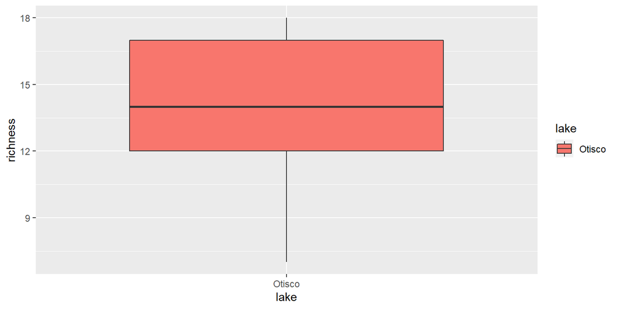

```r
ggplot(thesis.df, aes(lake, richness, fill = lake)) +
  geom_boxplot()
```

# Conclusions

1. The relative abundance of Diptera taxa in Otisco Lake ranged from 3.3057851 to 89.6551724.
2. The median taxonomic richness observed in Otisco Lake was 14.